# Lecture 06: Online and face-to-face testing

Running good studies

Dr. Gordon Wright

g.wright@gold.ac.uk

November 13, 2023

## Week 6, Let’s go!

- Social Psychology Essay Tutorial this week
- Have you done your reading and prepared?
- A word on attendance and independent study

# Any Questions?

## The Weeks ahead

Every group needs to apply for (and receive) ethical approval prior to the Winter Break. - Review the Ethics Page on the VLE - The same process you will use next year - 1 application per group - pre-approved by Lab Tutors - Planning is required and turnaround is 1 week - We deep dive ethics next week (week 7) - but review the materials in advance

# It’s time to get practical

## ‘Operationalisation’ of variables

Operationalisation of variables requires a consideration of the reliability and validity of the method of operationalisation.

Operationalisation of variables also requires specification of the scale of measurement: nominal, ordinal, interval, or ratio.

Finally, operationalisation of variables can also specify details of the measurement procedure.

See Howitt and Cramer Chapter 3.3 (Box Research Example - Condon & Crano 1988)

## Attitude similarity and interpersonal attraction

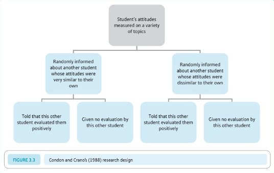

## Their DV (consider pros and cons)

This person would like (dislike) me

This person would like (dislike) working with me in an experiment

## The Student Room (question)

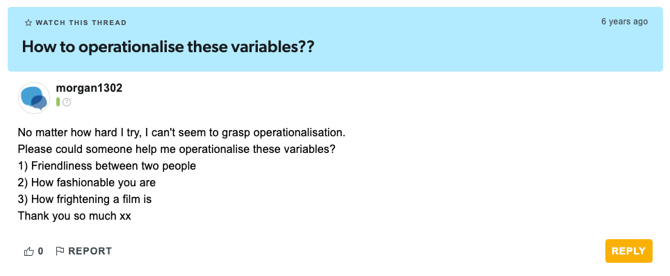

## The Student Room (answer 1)

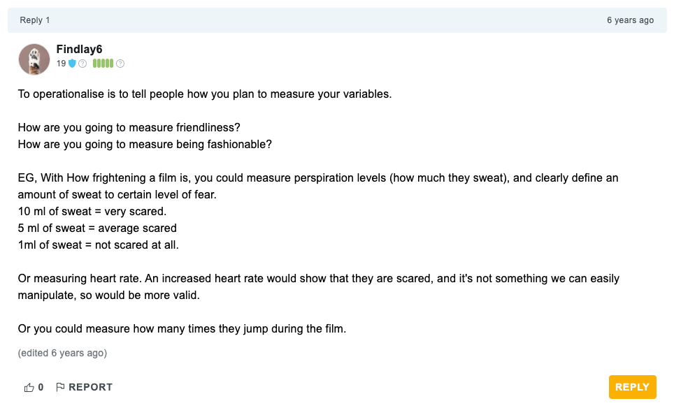

## The Student Room (answer 2)

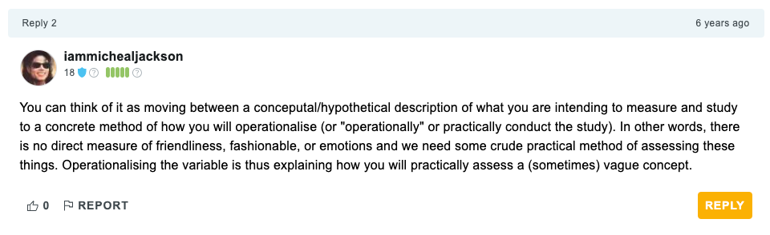

## Of great importance that you reflect on this for your MD too

How have you defined your variables of interest?

- IVs and DVs

How have you measured or categorised your variables of interest?

- e.g. Social Media use
- Gender
- Frequency or low/high extraversion

## **The research process**

**Note**

- Develop research aims
- Specify research questions/hypotheses related to these aims
- Identify relevant constructs and concepts
- Translate constructs and concepts into variables (i.e., a logical set of characteristics/features)
- Translate variables into measurements (i.e., the quantification of characteristics/features)

## Quantitative Research

A systematic examination of relationships between variables

‘Variables’ are ‘translated’ from concepts, constructs or phenomena

Could be critiqued as ‘reductionist’

## Types of Variable

Independent Variable

- Experimental - The variable I manipulate
- Non-Experimental / Quasi-Experimental - Comparison between pre-existing groups

Dependent Variable

## Types of Measurement

Nominal/Categorical

- Male/Female/…
- Vegan / Vegetarian
- Smoker/Non-Smoker

## Types of Measurement

Ordinal

Numbers representing a rank position in a group

Not representative of an actual definite number/score/value - without information about the ‘gap’ between numbers

- First, second, third
- Tallest/Shortest

## Types of Measurement

Interval

Numbers represent equal units giving information about the ‘gap’ between numbers

- Temperature
- Psychological Scales

## Types of Measurement

Ratio

Interval measurements with an absolute zero, of equal units,

- Weight
- Length
- Time/Reaction time*

## Median Splits

‘Cutting’ a distribution in half at the mid-point - with 50% on each side of the cut

## Median Splits can be considered problematic

**Beware!**

We often suggest a median split to dichotomise a continuous variable, e.g. for the purposes of creating a 2 level IV.

It’s a useful exercise in calculating a ‘computed variable’ in SPSS or Jamovi

It is NOT best-practice usually. Why not?

It is a key learning outcome that you are able to perform a standardised analysis, specifically, the 2x2 ANOVA with any necessary assumption checks and post-hocs + plots

## Think about this

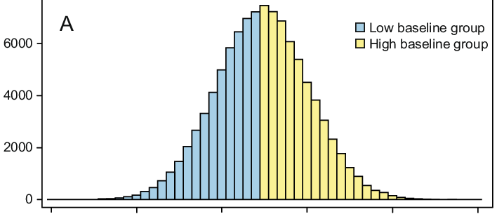

## Operationalisation, measurement and definitions impact…

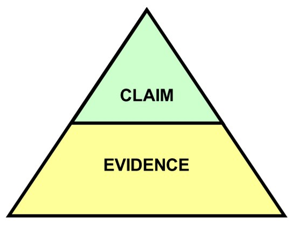

## Summary of part 1

You should think carefully about:

- How you define your variables - this is probably a part of the introduction that students DON’T think about enough
- How you measure or categorise your variables (IVs and DVs) - this is probably the single thing I look at first when peer-reviewing research!
- How well your manipulation does what it claims to. Does you manipulation bring the thing it proposed to to life well?

# Running Experiments online or face to face

## Comparing Experiment Modalities

- Online Surveys and Experiments
  - Qualtrics - For surveys, stimulus presentation that don’t require accurate timing
  - Gorilla.sc - For ‘experimental’ tasks with complex stimulus > presentation or that require response time measures or push-button > responses etc.
- Face-to-Face Experiments

## Online Surveys and Experiments with Qualtrics

### Overview

- A powerful tool for creating and distributing online surveys
- Widely used in psychological research
- We have an institutional licence and so it is FREE
- No specialist support - has excellent online support

## Pros of Qualtrics

### Accessibility

- Reach a wide, diverse audience (if necessary)
- Accessible by anyone with a phone or laptop etc

### Cost-Effective

- Low ‘cost’ compared to face-to-face

### Data Management

- Automated data collection, scoring and storage
- Relatively easy to analyze and export data - but not always simple

### Customization

- Highly customizable surveys and experiments (video, photos, audio, vignettes)
- Supports various question types and logic

## Cons of Qualtrics

### Limited Human Interaction

- Lack of personal interaction can affect responses
- You put a huge amount of trust in the participant
- Not always easy to manage ethical challenges properly

## Cons of Qualtrics (continued)

### Response Authenticity

- Higher risk of dishonest or inattentive responses (maybe?)

#### Sampling Bias

- Potential for non-representative samples

## Introduction to experiments using Gorilla.sc

### Gorilla.sc: highly controlled online Psychological Research

- A comprehensive online tool for behavioral research
- Facilitates creation, deployment, and analysis of experiments

## Core Features of Gorilla.sc

### User-Friendly Interface

- Intuitive design for researchers of all levels
- Drag-and-drop experiment builder

### Requires ‘tokens’ to run

- You will need to apply for ‘tokens’ to apply for ethics, and to run the study.
- There is usually a limited supply as there is a cost associated with this.

### Versatile Experiment Design

- Supports a wide range of experimental paradigms
- Customizable to suit various research needs

## Experiment Creation with Gorilla.sc

### Building Blocks

- Use ‘widgets’ and ‘tasks’ to construct experiments
- Easily integrate surveys, quizzes, and cognitive tasks

### Advanced Customization

- Incorporate complex experimental logic
- Customize with CSS and JavaScript for unique requirements

## Data Collection and Analysis

### Real-Time Data Collection

- Gather data securely and efficiently
- Access participant responses in real-time

### Analytical Tools

- Built-in tools for basic data analysis
- Export data for advanced analysis in other software e.g. SPSS

## Collaboration and Sharing

### Team Collaboration

- Share experiments and data with team members
- Collaborate on experiment design and analysis

### Participant Recruitment

- Still needs to be managed via sources outside of Gorilla

## Gorilla.sc in Psychological Research

### Broad Application

- Suitable for cognitive, social, and clinical psychology
- Ideal for remote and large-scale studies

### Impact on Mini-Dissertations

- Increases the reach of psychological studies requiring complex stimulus or timing
- Not easy to get up and running with this tool
- No specialist support - has excellent templates and online support

## Face-to-Face Experiments

### Overview

- Traditional method of conducting experiments
- Involves direct interaction with participants

## Pros of Face-to-Face Experiments

### Enhanced Interaction

- Direct human interaction enriches data quality

### Controlled Environment

- Better control over experimental conditions

### Immediate Feedback

- Opportunity for immediate clarification and feedback

### Participant Authenticity

- Lower risk of false responses (maybe?)

## Cons of Face-to-Face Experiments

### Higher Costs

- Greater resource and time investment (maybe?)

### Limited Reach

- Restricted to participants’ geographical location

### Time-Consuming

- Scheduling and conducting sessions takes time

### Potential Biases

- Risk of experimenter or social desirability biases

## Conclusion

### Choosing the Right Method

- Depends on research goals, resources, and target population
- Both methods offer unique advantages and challenges

### Tailoring to Research Needs

- Consider the nature of your study and participant accessibility
- Balance between quality, ‘cost’, and reach

# Questions?

## Lab activities

Qualtrics (Many of you will use this!)

- Log in to an account with your Goldsmiths ID!!
- 10% of you will apply for the wrong type of account and be stuck for 2 weeks

Familiarise yourself with the Ethics Application process

Consider the steps required to bring your study to life!

## References

Research Methods Lecture 06 - Online and face-to-face testing